# 1. Linear Regression

## 3.2. Logistic Regression using Scikit-Learn

We can implement logistic regression from scratch in Python, but instead, we will use scikit-learn for convenience and efficiency.

As with the perceptron, scikit-learn handles the intercept internally, so the design matrix below contains no column of ones. Two further points about the library implementation are worth knowing.

- Scikit-learn applies $L_2$ regularization by default, adding a penalty on $\lVert \omega \rVert^2$ to the objective. The strength is controlled by the parameter `C`, where a smaller `C` means stronger regularization. This is why the coefficients obtained from the library may differ slightly from those obtained by maximizing the unpenalized log-likelihood by hand.
- The method `predict` returns hard class labels obtained by thresholding at $0.5$, while `predict_proba` returns the underlying probabilities. The probabilities are usually the more informative output, and the threshold of $0.5$ is a convention that should be reconsidered whenever the two types of error carry different costs.

$$ \begin{align*} \omega &= \begin{bmatrix} \omega_1 \\ \omega_2\end{bmatrix}, \qquad \omega_0, \qquad x = \begin{bmatrix} x_1 \\ x_2\end{bmatrix}\\ \\ X &= \begin{bmatrix} \left(x^{(1)}\right)^T \\ \left(x^{(2)}\right)^T \\ \left(x^{(3)}\right)^T \\ \vdots\end{bmatrix} = \begin{bmatrix} x_1^{(1)} & x_2^{(1)} \\ x_1^{(2)} & x_2^{(2)} \\ x_1^{(3)} & x_2^{(3)} \\ \vdots & \vdots \\\end{bmatrix}\\ \\ y & = \begin{bmatrix} y^{(1)}\\ y^{(2)} \\y^{(3)} \\ \vdots \end{bmatrix} \end{align*} $$

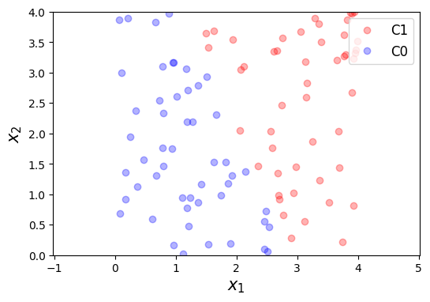

```python
# datat generation

m = 100
w0 = -6
w = np.array([[2], [1]])
X = np.hstack([4*np.random.rand(m,1), 4*np.random.rand(m,1)])

w = np.asmatrix(w)
X = np.asmatrix(X)

y = 1/(1 + np.exp(-w0-X*w)) > 0.5

C1 = np.where(y == True)[0]
C0 = np.where(y == False)[0]

y = np.empty([m,1])
y[C1] = 1
y[C0] = 0

plt.figure(figsize = (6, 4))
plt.plot(X[C1,0], X[C1,1], 'ro', alpha = 0.3, label = 'C1')
plt.plot(X[C0,0], X[C0,1], 'bo', alpha = 0.3, label = 'C0')
plt.xlabel(r'$x_1$', fontsize = 15)
plt.ylabel(r'$x_2$', fontsize = 15)
plt.legend(loc = 1, fontsize = 12)
plt.axis('equal')
plt.xlim([0,4])
plt.ylim([0,4])
plt.show()
```

```python
from sklearn import linear_model

clf = linear_model.LogisticRegression(solver = 'lbfgs')
clf.fit(np.asarray(X), np.ravel(y))
```

```
LogisticRegression()
```

```python
clf.coef_
```

```
array([[3.21453711, 1.29943009]])
```

```python
clf.intercept_
```

```
array([-9.18960726])
```

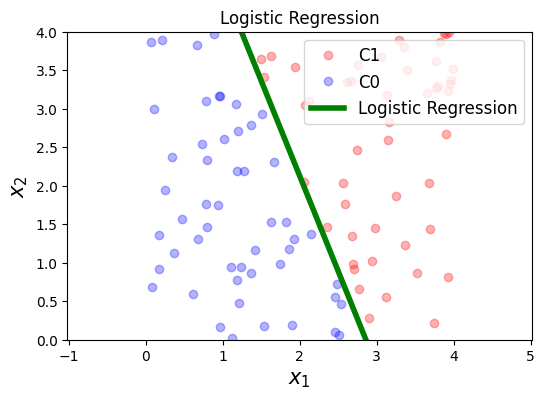

```python
w0 = clf.intercept_[0]
w1 = clf.coef_[0,0]
w2 = clf.coef_[0,1]

xp = np.linspace(0,4,100).reshape(-1,1)
yp = - w1/w2*xp - w0/w2

plt.figure(figsize = (6, 4))
plt.plot(X[C1,0], X[C1,1], 'ro', alpha = 0.3, label = 'C1')
plt.plot(X[C0,0], X[C0,1], 'bo', alpha = 0.3, label = 'C0')
plt.plot(xp, yp, 'g', linewidth = 4, label = 'Logistic Regression')
plt.title('Logistic Regression')
plt.xlabel(r'$x_1$', fontsize = 15)
plt.ylabel(r'$x_2$', fontsize = 15)
plt.legend(loc = 1, fontsize = 12)
plt.axis('equal')
plt.xlim([0,4])
plt.ylim([0,4])
plt.show()
```

## 3.3. Cross-Entropy

You might have seen the concept of **entropy** in physics. In fact, the concept of entropy is closely related to the **cross-entropy** that we just encountered in logistic regression.

**Entropy in Physics**

In statistical physics, entropy measures the uncertainty or disorder of a system:

$$ S = -k_B \sum_{i} p_i \log p_i, $$

where:

- $ S $ is the [Boltzmann entropy](https://en.wikipedia.org/wiki/Boltzmann%27s_entropy_formula).
- $ k_B $ is Boltzmann's constant.
- $ p_i $ is the probability of the system being in state $ i $.

Entropy quantifies how much "randomness" or "information" is needed to describe the system's configuration.

The parallel is not a loose analogy. Shannon arrived at the same functional form independently, in the context of communication, by asking how many bits are needed on average to encode the outcome of a random variable. In information theory the entropy is written

$$ H(p) = - \sum_i p_i \log p_i , $$

which is the Boltzmann expression with $k_B$ set to one. Entropy is minimized, and equal to zero, when one outcome is certain, and it is maximized when all outcomes are equally likely. In both fields the interpretation is the same: entropy measures how much we do not know.

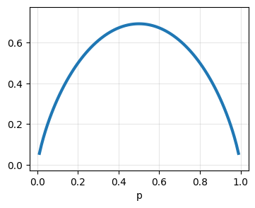

```python
import numpy as np
import matplotlib.pyplot as plt
%matplotlib inline

p = np.linspace(0.01, 0.99, 100)
S = -p*np.log(p) - (1-p)*np.log(1-p)

plt.figure(figsize = (4, 3))
plt.plot(p, S, linewidth = 3)
plt.xlabel('p')
plt.axis('equal')
plt.grid(alpha = 0.3)
plt.show()
```

**Cross-Entropy in Logistic Regression**

In logistic regression, cross-entropy measures how well the predicted probability distribution matches the true distribution:

$$ \mathcal{L} = - \sum_{i} \left[\, y_i \log \hat{y}_i + (1 - y_i) \log (1 - \hat{y}_i) \,\right], $$

where:

- $ y_i $ is the true label (1 or 0).
- $ \hat{y}_i $ is the predicted probability for class 1.
- The loss is high when the model predicts probabilities far from the true class.

**Connecting the Concepts**

- In physics, Boltzmann entropy measures the disorder of a system based on probabilities of different states.
- In machine learning, cross-entropy loss measures the "disorder" or "uncertainty" when the predicted probabilities do not align with the true labels.
- Improving classification performance therefore corresponds to reducing the uncertainty between the predicted and the true distributions.

**Why It Is Called Cross-Entropy**

The prefix "cross" indicates that two distributions are involved rather than one. Ordinary entropy $H(p) = -\sum_i p_i \log p_i$ measures the uncertainty of a single distribution $p$. Cross-entropy

$$ H(p, q) = - \sum_i p_i \log q_i $$

measures the average number of bits needed to encode outcomes drawn from the true distribution $p$ when the encoding was designed for a different distribution $q$. It is minimized, and equal to $H(p)$, exactly when $q = p$. The excess, $H(p,q) - H(p)$, is the Kullback-Leibler divergence, a measure of how far the predicted distribution is from the true one.

In our setting $p$ is the true label, a distribution placing all of its mass on one class, and $q$ is the model's predicted probability. Minimizing the cross-entropy therefore means adjusting the model until its predicted distribution matches the observed labels as closely as possible.

**The Connection to Section 3.1**

Note that nothing new has been introduced here. The cross-entropy is simply the negative log-likelihood derived earlier, renamed. Maximizing the likelihood of the observed labels and minimizing the cross-entropy between the true and predicted distributions are the same operation described in two vocabularies, one from statistics and one from information theory. The name matters mainly because deep learning frameworks use the second one: what TensorFlow calls `sigmoid_cross_entropy_with_logits` is the objective we derived by hand in Section 3.1.

# 4. Deep Learning Libraries

Everything up to this point could be implemented with NumPy alone, because the models were small and their gradients could be derived by hand. That approach does not scale. A modern network has millions of parameters and a loss function whose derivative no one would attempt to write out, so a different tool is needed.

Deep learning frameworks solve three problems at once.

- **Automatic differentiation.** The framework records the operations performed during the forward computation and applies the chain rule mechanically to obtain exact gradients. Derivatives no longer have to be derived by hand, and they are not approximated by finite differences either.
- **Hardware acceleration.** The same code runs on a GPU, where the matrix operations that dominate training are executed in parallel across thousands of cores.
- **Reusable components.** Layers, activation functions, loss functions, and optimizers are provided as standard building blocks, so that specifying a model becomes a matter of composition rather than implementation.

The three most widely used frameworks are introduced below. TensorFlow is used for the examples in this notebook.

**TensorFlow**

[figure not shown]

- Platform: Linux, Mac OS, Windows
- Written in: C++, Python
- Interface: Python, C/C++, Java, Go, R
- https://www.tensorflow.org/

**Keras**

- https://keras.io/

**PyTorch**

[figure not shown]

- https://pytorch.org/

# 5. TensorFlow

[TensorFlow](https://www.tensorflow.org) is an open-source software library for deep learning.

- It provides a framework for performing computation efficiently, and it can make use of the GPU (Graphics Processing Unit) to accelerate computation further. TensorFlow is controlled through a simple Python API.
- TensorFlow is one of the most widely used libraries for implementing machine learning and other algorithms that involve a large number of mathematical operations. It was developed by Google and is among the most popular machine learning libraries on GitHub.
- TensorFlow gets its name from "tensors", which are arrays of arbitrary dimensionality.
- The "flow" part of the name refers to computation flowing through a graph. Training and inference in a neural network, for example, involves the propagation of matrix computations through many nodes in a computational graph.

The computational graph is the idea that makes automatic differentiation possible, and it is worth understanding rather than treating as an implementation detail. When an expression such as $(\omega - 4)^2$ is evaluated, TensorFlow does not merely compute a number. It records the sequence of elementary operations that produced it: a subtraction, then a squaring. Each of these has a known derivative, so the chain rule can be applied backwards through the recorded sequence to obtain the derivative of the result with respect to any input.

Two consequences follow, and both matter in practice. The gradients obtained are exact, not finite-difference approximations, so no step size has to be chosen and no truncation error is incurred. And the cost of computing the gradient with respect to all parameters is comparable to the cost of a single forward evaluation, regardless of how many parameters there are. This second property is what makes training a network with millions of parameters feasible at all.

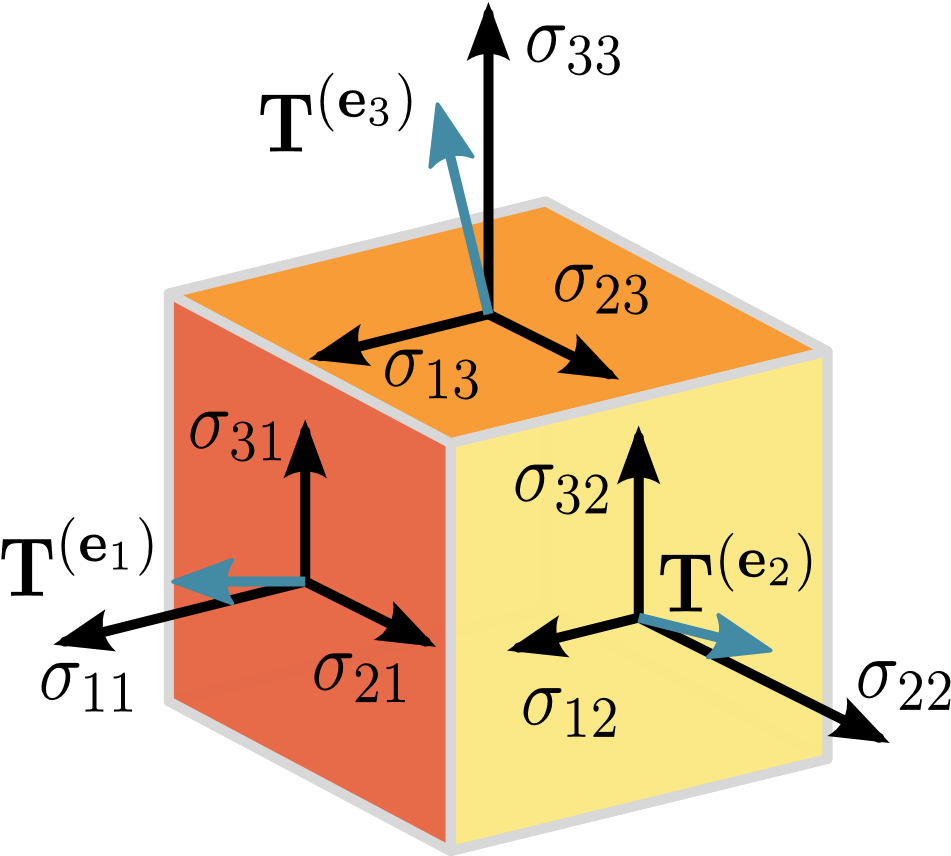

Side note:

- In solid mechanics, a tensor is a multi-dimensional array of numbers that describes the physical state of a material. Tensors are used to describe physical quantities like stress and strain, which have magnitude and two or more directions.
- While the specific applications of tensors in TensorFlow and solid mechanics differ, the underlying concept, a mathematical object capable of representing multi-dimensional relationships, remains the same in both cases.

## 5.1. TensorFlow as Optimization Solver

Here we demonstrate how to implement gradient descent in TensorFlow as a way of becoming familiar with the framework.

This example illustrates how TensorFlow handles automatic differentiation and gradient descent updates, which is useful when building deep learning models and optimizing more complex loss functions.

The example below is deliberately trivial. The function $(\omega - 4)^2$ is a parabola whose minimum is obviously at $\omega = 4$, and no numerical method is needed to find it. That is exactly the point: because the answer is known in advance, any discrepancy in the output is attributable to the procedure rather than to the problem.

Watch for three elements in the code, since every training loop in deep learning contains the same three, no matter how complicated the model.

1. The variable to be optimized is declared as a `tf.Variable`, which marks it as something TensorFlow should track and update. Ordinary constants are not tracked.
2. The loss is evaluated inside a `tf.GradientTape` context, which is what records the operations for later differentiation.
3. An optimizer applies the computed gradient to the variable, and the whole sequence is repeated in a loop.

Observe also how the learning rate behaves. Too small, and the iterations creep toward the answer; too large, and the updates overshoot and may diverge. This parameter has no automatic setting and remains one of the most consequential choices in training any model.

$$\min_{\omega}\;\;(\omega - 4)^2$$

```python
import numpy as np
import matplotlib.pyplot as plt
import tensorflow as tf
%matplotlib inline
```

```
 optimal w = 3.979385
```

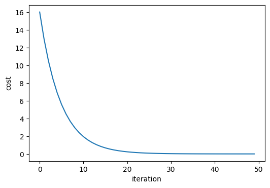

```python
w = tf.Variable(0, dtype = tf.float32)

LR = 0.05

# Training
cost_record = []

for i in range(50):
    with tf.GradientTape() as tape:
        cost = w*w - 8*w + 16
        w_grad = tape.gradient(cost, w)

    cost_record.append(cost)
    w.assign_sub(LR * w_grad)

print("\n optimal w =", w.numpy())
print("\n")

plt.figure(figsize = (6, 4))
plt.plot(cost_record)
plt.xlabel('iteration')
plt.ylabel('cost')
plt.show()
```

## 5.2. Linear Regression using TensorFlow

We now return to the problem of Chapter 1, but solve it by a completely different route. There the optimum was obtained in one step from the normal equation $\theta = (A^TA)^{-1}A^Ty$. Here it is obtained by taking many small steps downhill on the loss surface.

For linear regression this is a step backwards in efficiency, and it should be recognized as such. Its value is that the iterative approach continues to work when the closed form does not exist, which is the situation for every model beyond this chapter. Solving a problem whose exact answer we already know is the safest way to confirm that the iterative machinery is correct, and it also allows the two answers to be compared directly.

$$\hat{y} = \omega x + b$$

- Given $x$ and $y$
- Want to estimate $\omega$ and $b$

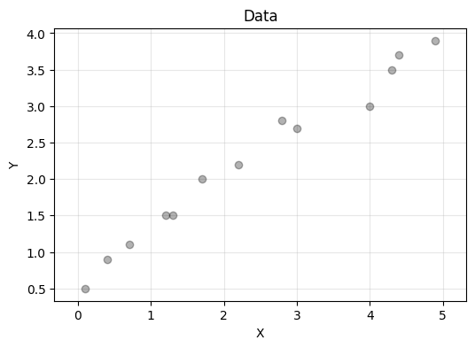

```python
# data generation
# data points in column vector [input, output]

train_x = np.array([0.1, 0.4, 0.7, 1.2, 1.3, 1.7, 2.2, 2.8, 3.0, 4.0, 4.3, 4.4, 4.9]).reshape(-1, 1)
train_y = np.array([0.5, 0.9, 1.1, 1.5, 1.5, 2.0, 2.2, 2.8, 2.7, 3.0, 3.5, 3.7, 3.9]).reshape(-1, 1)

m = train_x.shape[0]

plt.figure(figsize = (6, 4))
plt.plot(train_x, train_y, 'ko', alpha = 0.3)
plt.title('Data')
plt.xlabel('X')
plt.ylabel('Y')
plt.axis('equal')
plt.grid(alpha = 0.3)
plt.xlim([0, 5])
plt.show()
```

- Given $(x_i, y_i)$ for $i=1,\cdots, m$

$$ \hat{y}_{i} = \omega x_{i} + b \; \quad \text{ such that }\quad \min\limits_{\omega, b}\sum\limits_{i = 1}^{m} (\hat{y}_{i} - y_{i})^2$$

```
 optimal w = [[0.74257565]]

 optimal b = [[0.41717836]]
```

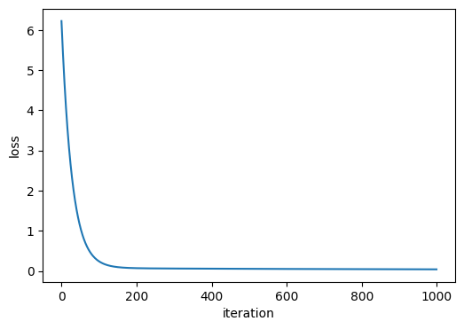

```python
LR = 0.001
n_iter = 1000

w = tf.Variable([[0]], dtype = tf.float32)
b = tf.Variable([[0]], dtype = tf.float32)

loss_record = []

for i in range(n_iter):
    with tf.GradientTape() as tape:
        cost = tf.reduce_mean(tf.square(w*train_x + b - train_y))
        w_grad, b_grad = tape.gradient(cost, [w,b])

    loss_record.append(cost)
    w.assign_sub(LR * w_grad)
    b.assign_sub(LR * b_grad)

w_val = w.numpy()
b_val = b.numpy()
print("\n optimal w =", w_val)
print("\n optimal b =", b_val)
print("\n")

plt.figure(figsize = (6, 4))
plt.plot(loss_record)
plt.xlabel('iteration')
plt.ylabel('loss')
plt.show()
```

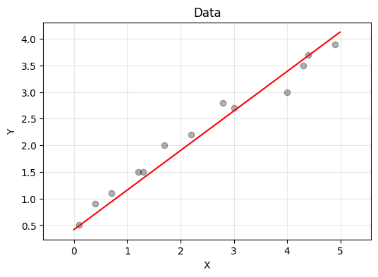

```python
xp = np.arange(0, 5, 0.01).reshape(-1, 1)
yp = w_val*xp + b_val

plt.figure(figsize = (6, 4))
plt.plot(train_x, train_y, 'ko', alpha = 0.3)
plt.plot(xp, yp, 'r')
plt.title('Data')
plt.xlabel('X')
plt.ylabel('Y')
plt.axis('equal')
plt.grid(alpha = 0.3)
plt.xlim([0, 5])
plt.show()
```

## 5.3. Logistic Regression using TensorFlow

This is the same model derived in Chapter 3, now expressed in TensorFlow. Comparing the two implementations is instructive: the mathematics is identical, but the gradient formula derived by hand in Section 3.1 no longer appears anywhere in the code. It is obtained automatically by differentiating the loss.

This is the pattern that carries forward into deep learning. From this point on, specifying a model means stating the architecture and the loss function, and the learning rule follows from them without further human intervention.

$$ \begin{align*} \omega &= \begin{bmatrix} \omega_0 \\ \omega_1 \\ \omega_2\end{bmatrix}, \qquad x = \begin{bmatrix} 1 \\ x_1 \\ x_2\end{bmatrix}\\ \\ X &= \begin{bmatrix} \left(x^{(1)}\right)^T \\ \left(x^{(2)}\right)^T \\ \left(x^{(3)}\right)^T \\ \vdots\end{bmatrix} = \begin{bmatrix} 1 & x_1^{(1)} & x_2^{(1)} \\ 1 & x_1^{(2)} & x_2^{(2)} \\ 1 & x_1^{(3)} & x_2^{(3)} \\ \vdots & \vdots & \vdots \\\end{bmatrix}, \quad y = \begin{bmatrix} y^{(1)}\\ y^{(2)} \\y^{(3)} \\ \vdots \end{bmatrix} \end{align*} $$

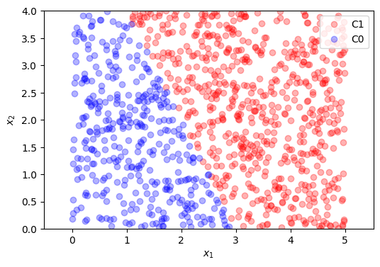

```python
# datat generation

m = 1000
true_w = np.array([[-6], [2], [1]])
train_X = np.hstack([np.ones([m,1]), 5*np.random.rand(m,1), 4*np.random.rand(m,1)])

true_w = np.asmatrix(true_w)
train_X = np.asmatrix(train_X)

train_y = 1/(1 + np.exp(-train_X*true_w)) > 0.5

C1 = np.where(train_y == True)[0]
C0 = np.where(train_y == False)[0]

train_y = np.empty([m,1])
train_y[C1] = 1
train_y[C0] = 0

plt.figure(figsize = (6, 4))
plt.plot(train_X[C1,1], train_X[C1,2], 'ro', alpha = 0.3, label = 'C1')
plt.plot(train_X[C0,1], train_X[C0,2], 'bo', alpha = 0.3, label = 'C0')
plt.xlabel(r'$x_1$')
plt.ylabel(r'$x_2$')
plt.legend(loc = 1)
plt.axis('equal')
plt.ylim([0,4])
plt.show()
```

$$ \begin{align*} \ell(\omega) = \log \mathscr{L}(\omega) &= \sum_{i=1}^{m} y^{(i)} \log h_{\omega} \left(x^{(i)} \right) + \left(1-y^{(i)} \right) \log \left(1-h_{\omega} \left(x^{(i)} \right) \right)\\\\ &\Rightarrow \frac{1}{m} \sum_{i=1}^{m} y^{(i)} \log h_{\omega} \left(x^{(i)} \right) + \left(1-y^{(i)} \right) \log \left(1-h_{\omega} \left(x^{(i)} \right) \right) \end{align*} $$

In practice, optimization problems in machine learning are commonly formulated as the minimization of an objective function (or loss function) rather than the maximization.

Two changes are made in the expressions below, and each has a practical reason.

- **Division by $m$.** Replacing the sum by an average makes the loss independent of the number of training examples. Without it, a suitable learning rate for a dataset of $100$ points would be far too large for one of $10{,}000$ points, since the gradient would scale with the dataset size.
- **Negation.** Optimizers in every deep learning framework are written to minimize, so a maximization problem is converted by flipping the sign. Maximizing the log-likelihood and minimizing the negative log-likelihood, which is the cross-entropy of Section 3.3, are the same problem.

$$ \begin{align*} \hat{\omega} &= \arg\max_{\omega} \ell(\omega)\\ & = \arg \min_{\omega} -\ell(\omega) \end{align*} $$

```
[[-8.113688 ]
 [ 2.872544 ]
 [ 1.2784871]]
```

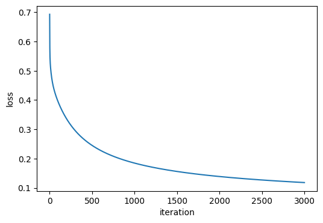

```python
LR = 0.1
n_iter = 3000

w = tf.Variable([[0],[0],[0]], dtype = tf.float32)
train_x = tf.constant(train_X, dtype = tf.float32)
train_y = tf.constant(train_y, dtype = tf.float32)

loss_record = []

for i in range(n_iter):
    with tf.GradientTape() as tape:
        y_pred = tf.sigmoid(tf.matmul(train_x, w))
        loss = - train_y*tf.math.log(y_pred) - (1-train_y)*tf.math.log(1-y_pred)
        loss = tf.reduce_mean(loss)
        w_grad = tape.gradient(loss, w)

    loss_record.append(loss)
    w.assign_sub(LR * w_grad)

w_hat = w.numpy()
print(w_hat)
print("\n")

plt.figure(figsize = (6, 4))
plt.plot(loss_record)
plt.xlabel('iteration')
plt.ylabel('loss')
plt.show()
```

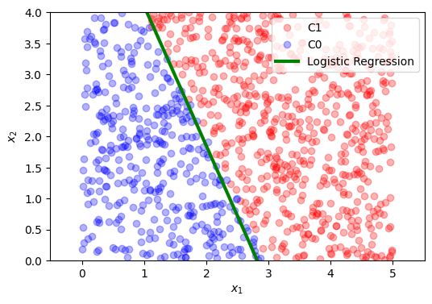

```python
xp = np.arange(0, 4, 0.01).reshape(-1, 1)
yp = - w_hat[1,0]/w_hat[2,0]*xp - w_hat[0,0]/w_hat[2,0]

plt.figure(figsize = (6, 4))
plt.plot(train_X[C1,1], train_X[C1,2], 'ro', alpha = 0.3, label = 'C1')
plt.plot(train_X[C0,1], train_X[C0,2], 'bo', alpha = 0.3, label = 'C0')
plt.plot(xp, yp, 'g', linewidth = 3, label = 'Logistic Regression')
plt.xlabel(r'$x_1$')
plt.ylabel(r'$x_2$')
plt.legend(loc = 1)
plt.axis('equal')
plt.ylim([0,4])
plt.show()
```

Instead of manually defining the cross-entropy loss function, TensorFlow's built-in functions can be utilized for greater convenience and efficiency.

The reason for preferring the built-in function is numerical, not merely a matter of convenience, and it is worth understanding because the same issue arises in every framework.

Computing the sigmoid first and then taking its logarithm invites disaster at the extremes. For a large negative input the sigmoid underflows to exactly $0$ in floating point, and $\log 0$ is $-\infty$, which propagates through the rest of the computation as `nan`. The built-in functions avoid forming the intermediate probability at all, combining the sigmoid and the logarithm into a single algebraically equivalent expression that remains stable for arguments of any magnitude.

This is the origin of the term **logits** appearing in the function names. A logit is the raw score $\omega^T x$ before the sigmoid is applied. These functions expect the logits as input, not the probabilities, and passing an already-squashed probability into them is a common and quiet error: the code runs, but the sigmoid is applied twice and the model trains poorly for no visible reason.

TensorFlow embedded functions

- [tf.nn.sigmoid_cross_entropy_with_logits](https://www.tensorflow.org/api_docs/python/tf/nn/sigmoid_cross_entropy_with_logits) for binary classification
- [tf.nn.softmax_cross_entropy_with_logits](https://www.tensorflow.org/api_docs/python/tf/nn/softmax_cross_entropy_with_logits) for multiclass classification

```
[[-154.34242 ]
 [  51.494408]
 [  25.676441]]
```

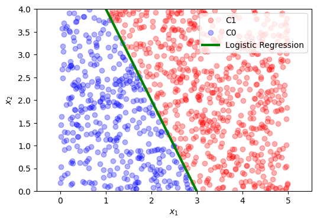

```python
LR = 0.05
n_iter = 1500

w = tf.Variable([[0],[0],[0]], dtype = tf.float32)
train_x = tf.constant(train_X, dtype = tf.float32)
train_y = tf.constant(train_y, dtype = tf.float32)

loss_record = []

for i in range(n_iter):
    with tf.GradientTape() as tape:
        y_pred = tf.matmul(train_x,w)
        loss = tf.nn.sigmoid_cross_entropy_with_logits(labels = train_y, logits = y_pred)
        w_grad = tape.gradient(loss, w)

    loss_record.append(loss)
    w.assign_sub(LR * w_grad)

w_hat = w.numpy()
print(w_hat)
print("\n")

xp = np.arange(0, 4, 0.01).reshape(-1, 1)
yp = - w_hat[1,0]/w_hat[2,0]*xp - w_hat[0,0]/w_hat[2,0]

plt.figure(figsize = (6, 4))
plt.plot(train_X[C1,1], train_X[C1,2], 'ro', alpha = 0.3, label = 'C1')
plt.plot(train_X[C0,1], train_X[C0,2], 'bo', alpha = 0.3, label = 'C0')
plt.plot(xp, yp, 'g', linewidth = 3, label = 'Logistic Regression')
plt.xlabel(r'$x_1$')
plt.ylabel(r'$x_2$')
plt.legend(loc = 1)
plt.axis('equal')
plt.ylim([0,4])
plt.show()
```

```python
%%javascript
$.getScript('https://kmahelona.github.io/ipython_notebook_goodies/ipython_notebook_toc.js')
```